# Lab 5 - Visualizations + Functions

ANTH 3900 / 5203

**Instructions:**

Please complete all components described below. All necessary data is available in your `Data` folder under the `Week 5 repository`.

**To submit:**

1. Clone your Week 5 Repo if you have not yet done so.
   - If you have done this earlier in the week, hit `Pull` under the Git tab. This will bring down the necessary data.
2. Create a new Quarto document. Title it “NAME_Lab5_Spring2026”.
3. At the very top of the document under title and author please be sure to put `embed-resources: true` AND `echo: true`. **This is a requirement each week!**
4. Complete all steps below.
5. Render and save. Make sure it is saved in the same folder as the RProject file for Week 5.
6. Commit and Push.

**Remember:**

1. Whenever you are using a package. You must open it. Remember `library()`. This must be in a code chunk in your document.
2. If you are using data, you must import it inside a code chunk. You cannot just use the import data button in the `Environment` pane.
3. Pay attention to your warnings and errors. They mean something.
- Remember, ggplot requires a `+` sign, not the pipe.
4. Remember to `set.seed()`.

# Questions

## Section 1: Simulation

1. Simulate data for 30 draws from a normal distribution where the mean is 120 and the standard deviation is 10. Save the object. Summarize the object.
2. Create a dataframe (n = 27) with 3 groups, 2 factors and two quantitative response variables. Use the replicate function `rep` for grouping and factor variables.
3. Sample 10 letters from the alphabet (a-z). Save and print the object.

## Section 2: Functions

1. Practice turning the following code snippets into functions. Think about what each function does. What would you call it? How many arguments does it need? You will end up with 3 functions. Note, your function must run and return an answer for full ccredit.

```r
mean(is.na(x))
mean(is.na(y))
mean(is.na(z))

x / sum(x, na.rm = TRUE)
y / sum(y, na.rm = TRUE)
z / sum(z, na.rm = TRUE)

round(x / sum(x, na.rm = TRUE) * 100, 1)
round(y / sum(y, na.rm = TRUE) * 100, 1)
round(z / sum(z, na.rm = TRUE) * 100, 1)
```

## Section 3: Conditional Statements

1. Finish the control-flow construct with the following behavior. Note, this means write a conditional if, else if, statement.
- If both `X` and `FB` are 15 or higher, set `social` equal to double the sum of `X` and `FB`.
- If both `X` and `FB` are strictly below 10, set `social` equal to half the sum of `X` and `FB`.
- In all other cases, set `social` equal to `X + FB`.
- Finally, print the resulting `social` variable.

## Section 4: For Loops

1. Write a for loop that iterates over the numbers 1 to 7 and prints the cube (`^3`) of each number using `print()`.
2. Write a while loop that prints out standard random normal numbers (use rnorm()) but stops (breaks) if you get a number bigger than 1. Note a standard normal has a mean 0 and standard deviation 1.

## Section 5: GGplot

**Notes:** 1. You will need the following packages if you have notr already opened them: `tidyverse`, `magrittr`, and `ggpubr`. * You may need to install `ggpubr`.

**Instructions:**

1. Import the following datasets into your environment: “sateeth.csv” and “saHeight.csv”. Name them anything you like.
2. Is there anything strange about these datasets? Remember, the first step of any analysis is to inspect the data. Tell me what you think is weird. Then make the requisite changes.

### Visualization # 1 (sateeth)

- Remove any rows where man_M1_R == -1. How many rows are left?
- Make column “man_M1_R” a factor
- Make the object “mytheme” with the following code:

```r
mytheme <- theme_bw() + theme(legend.key=element_blank(), legend.background=element_blank(), panel.grid.major=element_blank(), legend.tite=element_text(size=11, face='plain'))
```

- Create the following image:

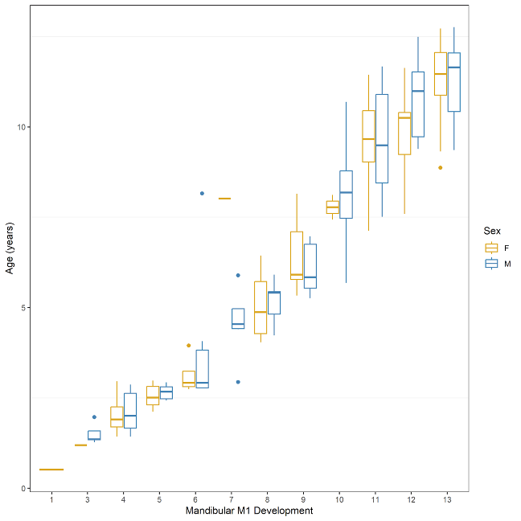

- Hints:
  - Use mytheme
  - Manually set the colors to “goldenrod” and “steelblue”

### Vizualization # 2 (saHeight)

- Change the name of column “weight (kg)” to “weight”
- Change weight from a character to an integer
  - You may get a warning. This is okay. What do you think it means?
- Use the following code to subset your data to a new object called “saH”:

```r
saHeight %>% filter(age_y != 1.32 & height_2 != 77.5, age_y !=4, height_2 != 88)
```

- Explore the relationship between “height_2” (x-axis) and “weight” (y-axis) in saH using an appropriate visualization
- Create the following visualization:

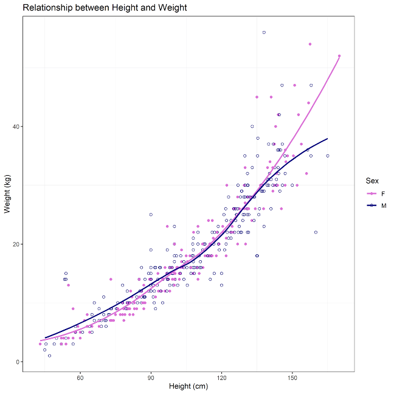

- Hints:
  - Colors are “orchid” and “navy”
  - Pay attention to the point shapes!
  - Pay attention to the legend!

### Visualization # 3 (saH)

**Create the following visualization:**

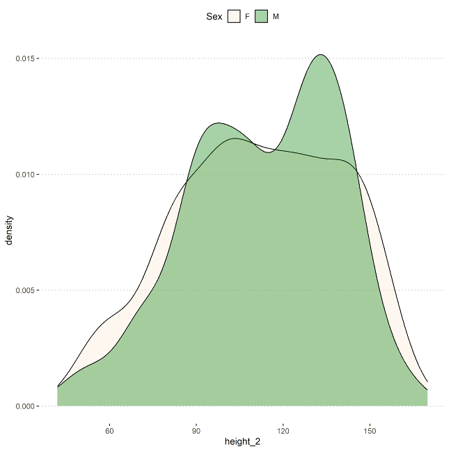

- Hints:
  - Use the `theme_pubclean()`
  - set alpha = 0.4
  - Use the following code:

```r
scale_fill_manual(guide=guide_legend(title="Sex"), values=c("antiquewhite","forestgreen"))
```

### Visualization #4

Use the following website and sateeth to create the following visualization: https://rpkgs.datanovia.com/ggpubr/index.html.

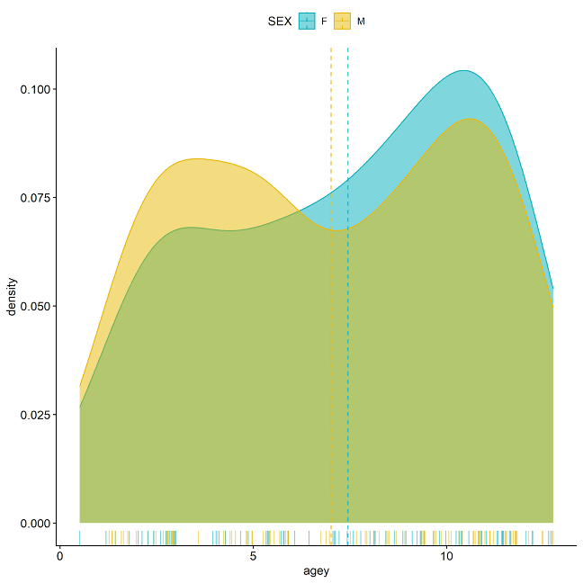

*Don’t forget to save, render, commit, and push!*